# Lab_4_OLEA

Author

Julian Olea

```r
library(dplyr)
library(ggplot2)
library(lubridate)
library(leaflet)
```

# 1: Read the data

```r
if (!file.exists("met_all.gz"))
  download.file(
    url = "https://raw.githubusercontent.com/USCbiostats/data-science-data/master/02_met/met_all.gz",
    destfile = "met_all.gz",
    method   = "libcurl",
    timeout  = 60
    )
met <- data.table::fread("met_all.gz")
```

# 2: Prepare the data

```r
data.table::week("2019-08-01 00:00:00")
```

```
[1] 31
```

```r
met %>%
  filter(temp > -17 & elev != 9999) %>%
  mutate(date = ymd_h(paste(year, month, day, hour, sep = " ")),
         week   = data.table::week(date)) %>%
  count(year, month, week) %>%
  arrange(year, month, week)
```

```
    year month  week      n
   <int> <int> <int>  <int>
1:  2019     8    31 297234
2:  2019     8    32 521560
3:  2019     8    33 527880
4:  2019     8    34 523806
5:  2019     8    35 446542
```

```r
met %>%
  filter(temp > -17
         & elev != 9999.0) %>%
  mutate(date = ymd_h(paste(year, month, day, hour, sep = " ")),
         week = data.table::week(date)) %>%
  group_by(year, month) %>%
  filter(week == min(week)) %>%
  ungroup() %>%
  group_by(USAFID) %>%
  summarise(mean_temp = mean(temp),
            mean_rh = mean(rh),
            mean_wind_sp = mean(`wind.sp`),
            mean_vis_dist = mean(`vis.dist`),
            mean_dew_point = mean(`dew.point`),
            mean_lat = mean(lat),
            mean_lon = mean(lon),
            mean_elev = mean(elev),
            .groups = "drop"
  ) %>%
  mutate(region = case_when(
    mean_lon > -98.00 & mean_lat > 39.71 ~ "NE",
    mean_lon <= -98.00 & mean_lat > 39.71 ~ "NW",
    mean_lon > -98.00 & mean_lat <= 39.71 ~ "SE",
    mean_lon <= -98.00 & mean_lat <= 39.71 ~ "SW"
  ),
  visibility = case_when(
    mean_vis_dist >= 0 & mean_vis_dist < 1000 ~ "fog",
    mean_vis_dist >= 1000 & mean_vis_dist < 6000  ~ "mist",
    mean_vis_dist >= 6000 & mean_vis_dist < 10000 ~ "haze",
    mean_vis_dist >= 10000 ~ "clear"
  ),
  elevation_category = case_when(
    mean_elev >= 252 ~ "high",
    mean_elev <= 252 ~ "low"
  )
  ) -> met_filtered
```

# 3: Use geom_violin to examine the wind speed and dew point by region

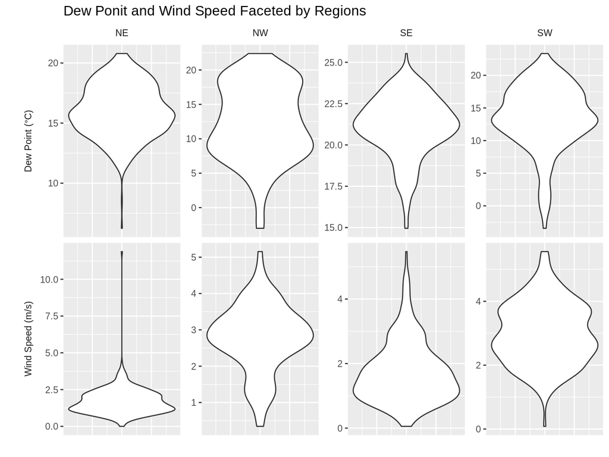

```r
met_filtered %>%
  select(mean_dew_point, mean_wind_sp, region) %>%
  tidyr::pivot_longer(cols = c(mean_dew_point, mean_wind_sp), names_to = "var", values_to = "val") %>%
  tidyr::drop_na() %>%

  ggplot(aes(x = 1, y = val)) +
  geom_violin() +
  ggh4x::facet_grid2(
    var ~ region,
    scales = "free_y",
    independent = "y",
    axes = "y",
    switch = "y",
    labeller = labeller(
      var = c(
        mean_dew_point = "Dew Point (°C)",
        mean_wind_sp   = "Wind Speed (m/s)"
      )
    )
  ) +
  theme(axis.text.x = element_blank(),
        axis.ticks.x = element_blank(),
        strip.placement = "outside",
        strip.background = element_blank(),
        strip.text.y.left = element_text(angle = 90)) +
  labs(x = "",
       y = "",
       title = "Dew Ponit and Wind Speed Faceted by Regions")
```

For the NE, SE, and SW regions, the dew point follows a unimodal distribution. Dew points for. NE and SW regions seem to be mostly distributed around the 15°C mark. For the SE region, the dew point seems to be mostly distributed around 21°C. The NW region interestingly has a bimodal distribution with the primary distribution being weighted aroun 9°C and the secondary distribution around 19 °C.

The wind speeds for the NE, NW,and SE regions seem to follow a unimodal distribution with the wind speeds being distributed primarily around 1.5, 3, and 1.5 m/s respectively. The SW region has a bimodal wind speed distribution with the wind speed primarily being distributed around 2 m’s and secondarily around 3.75 m/s.

# 4: Use geom_jitter with stat_smooth to examine the association between dew point and wind speed by region

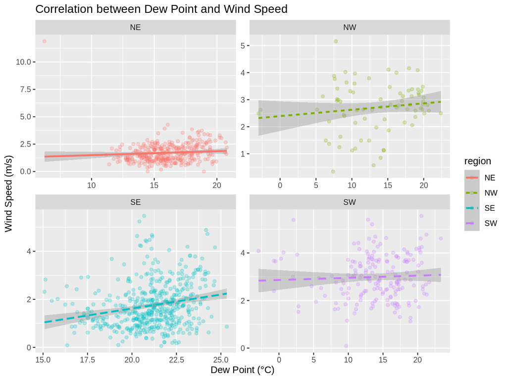

```r
met_filtered %>%
  select(mean_dew_point, mean_wind_sp, region) %>%
  tidyr::drop_na() %>%

  ggplot(aes(x = mean_dew_point, y = mean_wind_sp, color = region)) +
  geom_jitter(alpha = 0.25) +
  geom_smooth(aes(linetype = region), method = "lm") +
  facet_wrap( ~ region, ncol = 2, scales = "free") +
  labs(x = "Dew Point (°C)",
       y = "Wind Speed (m/s)",
       title = "Correlation between Dew Point and Wind Speed")
```

Across all four regions, dew point has a weak but positive correlation with wind speed (i.e. as dew point increases, wind speed also increases).

# 5: Use geom_bar to create barplots of the weather stations by elevation category colored by region

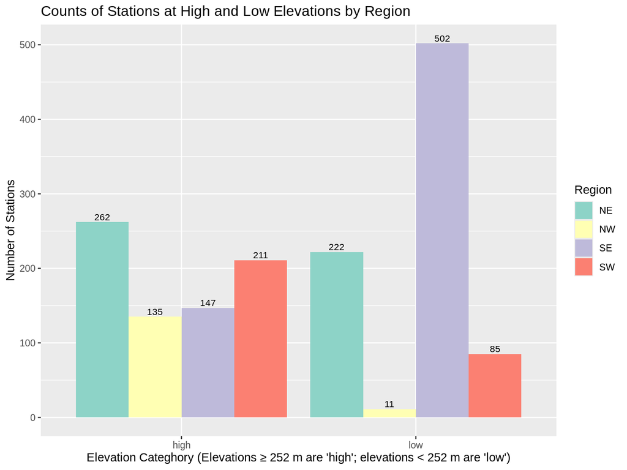

```r
met_filtered %>%
  select(USAFID, elevation_category, region) %>%
  tidyr::drop_na() %>%
  group_by(elevation_category, region) %>%
  summarise(n = n_distinct(USAFID), .groups = "drop") %>%

  ggplot(aes(x = elevation_category, y = n,  fill = region)) +
  scale_fill_brewer(palette = "Set3") +
  geom_bar(stat = "identity", position = "dodge") +
  geom_text(aes(label = n),
            position = position_dodge(width = 0.9),
            vjust = -0.3, size = 3) +
  labs(x = "Elevation Categhory (Elevations ≥ 252 m are 'high'; elevations < 252 m are 'low')",
       y = "Number of Stations",
       fill = "Region",
       title = "Counts of Stations at High and Low Elevations by Region")
```

Among the high elevation stations, the NE has the most stations with 262 stations. For the low elevation stations, the SE region has the most at 502 stations. For both elevation categories, the NW has the least stations.

# 6: Use stat_summary to examine mean dew point and wind speed by region with standard deviation error bars

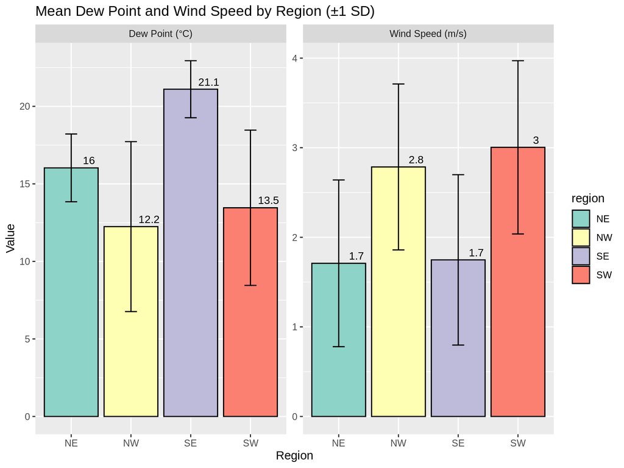

```r
met_filtered %>%
  select(mean_dew_point, mean_wind_sp, region) %>%
  tidyr::pivot_longer(cols = c(mean_dew_point, mean_wind_sp), names_to = "var", values_to = "val") %>%
  tidyr::drop_na() %>%

  ggplot(aes(x = region, y = val, fill = region)) +
  stat_summary(fun = mean, geom = "bar", color = "black") +
  stat_summary(fun.data = "mean_sdl", fun.args = list(mult = 1), mapping = aes(group = region), geom = "errorbar", width = 0.2) +
  stat_summary(fun = mean, geom = "text", aes(label = round(..y.., 1)), vjust = -0.5, color = "black", size = 3.5, position = position_nudge(x = 0.3)) +
  facet_wrap(~ var, scales = "free_y",
             labeller = labeller(
               var = c(
                 mean_dew_point = "Dew Point (°C)",
                 mean_wind_sp   = "Wind Speed (m/s)"
               ))) +
  scale_fill_brewer(palette = "Set3") +
  labs(
    x = "Region",
    y = "Value",
    title = "Mean Dew Point and Wind Speed by Region (±1 SD)"
  )
```

```r
met_filtered %>%
  tidyr::drop_na() %>%
  group_by(region) %>%
  summarise(sd_mean_dew_point = sd(mean_dew_point),
            sd_mean_windsp = sd(mean_wind_sp)
            )
```

```
# A tibble: 4 × 3
  region sd_mean_dew_point sd_mean_windsp
  <chr>              <dbl>          <dbl>
1 NE                  2.08          0.950
2 NW                  5.50          0.841
3 SE                  1.80          0.958
4 SW                  4.95          0.943
```

# 7: Make a map showing the spatial trend in relative humidity in the US

```r
colors <- colorFactor(
  palette = c("dodgerblue", "firebrick", "green", "magenta"),
  domain  = factor(met_filtered$region, levels = sort(unique(met_filtered$region)))
)


met_filtered %>%
  tidyr::drop_na() %>%
  arrange(desc(mean_rh)) %>%
  head(10) -> top10_rh

met_filtered %>%
  tidyr::drop_na() %>%
  leaflet() %>%
  addProviderTiles('OpenStreetMap') %>%
  addCircles(lat =~ mean_lat, lng =~ mean_lon, opacity = 1, fillOpacity = 1, radius = 500, color = ~colors(factor(region))) %>%
  addMarkers(~top10_rh$mean_lon, ~top10_rh$mean_lat, popup = ~as.character(top10_rh$mean_rh), label = ~as.character(top10_rh$mean_rh)) %>%
  addLegend(
    "bottomright",
    pal = colors,
    values = ~factor(region),
    title = "Region"
  )
```

[interactive chart not shown]

The stations with higher relative humidity tend to fall in the coastal or in the northern midwest states. The NW region has 5 of the 10 most humid sites. This is consistent with known weather patterns that characterize the PNW as a generally humid area that receives a lot of rain / snow during the winter months.

# 8: Use a ggplot extension (Using ggpubr to add r and p values to plot 4)

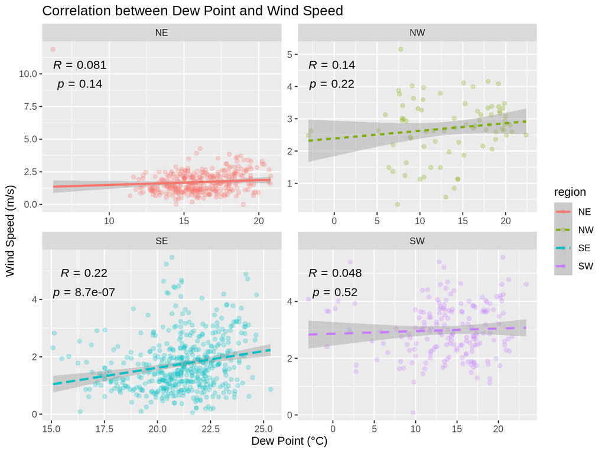

```r
met_filtered %>%
  select(mean_dew_point, mean_wind_sp, region) %>%
  tidyr::drop_na() %>%

  ggplot(aes(x = mean_dew_point, y = mean_wind_sp, color = region)) +
  geom_jitter(alpha = 0.25) +
  geom_smooth(aes(linetype = region), method = "lm") +
  ggpubr::stat_cor(
    aes(x = mean_dew_point, y = mean_wind_sp),
    method = "pearson",
    label.x.npc = "left",
    label.y.npc = "top",
    parse = FALSE,
    label.sep = "\n",
    size = 4,
    color = "black",
    inherit.aes = FALSE
  ) +
  facet_wrap( ~ region, ncol = 2, scales = "free") +
  labs(x = "Dew Point (°C)",
       y = "Wind Speed (m/s)",
       title = "Correlation between Dew Point and Wind Speed")
```

Now that we have p values, we can see that only the SE has a significant, weak positive correlation. All the other regions have p values > 0.05, suggesting that these weak positive correlations are not that robust.